# Комплексный spline-memory DPD: воспроизводимый BlackBox-эксперимент

**Краткий итог.** Notebook воспроизводит отдельный эксперимент на BlackBox capture: обучает вспомогательный GMP evaluator усилителя, замораживает его, калибрует причинный комплексный spline-memory DPD и проверяет каскад в правильном направлении. Итоговые числа формируются при полном запуске, а не перенесены из презентации.

**Статус доказательности: МОДЕЛЬ PA.** Это не `DPA_200MHz` и не `APA_200MHz`. После подачи предыскажённого сигнала физический PA не измерялся, поэтому результаты не доказывают физическую линеаризацию, превосходство над OpenDPD, выполнение требований Huawei или готовность к внедрению.

> **Конфиденциальность данных.** Эта самодостаточная версия содержит встроенную копию измеренных train/validation-данных. Перед внешней отправкой необходимо подтвердить разрешение на распространение capture.

| Пункт | Результат полного запуска |
| --- | --- |
| Набор данных | BlackBox capture, train 92 000 / validation 23 000 |
| PA evaluator | causal GMP, 189 комплексных коэффициентов; `-28.590 dB` NMSE |
| DPD | `((0, 0), (1, 1), (2, 2))`, `K=24`, ridge `1e-4` |
| Validation без / с DPD | `-16.010 / -17.192 dB` pooled NMSE |
| Улучшение | `1.182 dB` на frozen PA evaluator |
| Fast path | `27 MUL + 28 ADD + 3 magnitude + 6 LUT reads` / complex sample |
| Fixed-point | в этом BlackBox notebook не проверен |

```
x_desired → DPD → frozen PA evaluator → y_hat ≈ g·x_desired
```

Правильный путь проверки:

```
desired x_val → frozen DPD → frozen PA evaluator → y_hat → сравнение с g·x_val
```

Измеренный `y_val` в DPD при этой проверке не подаётся.

## 1. Цель, два этапа и границы утверждений

Комплексный отсчёт основной полосы имеет вид

$$ x[n] = I[n] + jQ[n]. $$

Реальный PA реализует нелинейный оператор `F`. Мы хотим найти такой предыскажатель `D`, чтобы

$$ F(D(x[n])) \approx g\,x[n]. $$

**Этап A — идентификация PA evaluator.** По измеренным парам $x\rightarrow physical\ PA\rightarrow y$ на train обучается $\hat P(x)\approx y$. После fit evaluator замораживается.

**Этап B — калибровка DPD.** Коэффициенты DPD оцениваются на train, после чего проверяется только deployment-like путь $x_{desired}\rightarrow DPD\rightarrow\hat P\rightarrow\hat y$. Круговая реконструкция известного `y_val` не используется.

В метаданных BlackBox неизвестны частота дискретизации, несущая, waveform и официальные границы полос. Поэтому PSD ниже — только визуальная диагностика в циклах на отсчёт; ACLR/ACPR не вычисляется.

```python
# Базовые импорты и настройки воспроизводимости.
from __future__ import annotations

import base64
import io
import hashlib
import json
import time
from pathlib import Path

import matplotlib.pyplot as plt
import numpy as np

np.random.seed(0)
np.set_printoptions(precision=5, suppress=True)
plt.style.use("seaborn-v0_8-whitegrid")
print("NumPy:", np.__version__)
```

```
NumPy: 2.5.1
```

```python
# Встроенные train/validation массивы BlackBoxData (сжатый NPZ, base64).
# Генератор notebook подставляет payload перед сохранением файла.
EMBEDDED_DATA_B64 = """UEsDBC0AAAAIAAAAIQDrcdnL//////////8PABQAdHJhaW5feF9yYXcubnB5…="""


def load_embedded_splits() -> dict[str, np.ndarray]:
    """Decode the portable train/validation payload from this notebook.

    Returns:
        A dictionary with raw complex ``train_x``, ``train_y``,
        ``val_x`` and ``val_y`` arrays plus a human-readable source.
    """
    binary = base64.b64decode(EMBEDDED_DATA_B64.encode("ascii"))
    with np.load(io.BytesIO(binary), allow_pickle=False) as payload:
        result = {name: np.asarray(payload[name], dtype=np.complex128) for name in (
            "train_x_raw", "train_y_raw", "val_x_raw", "val_y_raw"
        )}
    result["source"] = "embedded BlackBoxData train/validation payload"
    return result


print("embedded payload ready; source data are portable with this notebook")
```

```
embedded payload ready; source data are portable with this notebook
```

## 2. Данные, загрузка и дисциплина разбиения

Хронологическое разбиение зафиксировано заранее: 92 000 отсчётов train (`5000:97000`) и 23 000 validation (`97000:120000`). Sealed test не встроен и не открывается. Validation используется для сравнения архитектур и числа узлов, поэтому её итоговая метрика не является независимой test-оценкой.

При `USE_EMBEDDED_DATA=True` используется встроенный payload. Для MAT установите `False` и задайте `MAT_PATH`; ожидаются комплексные массивы `x`, `y`, `eRef` одинаковой длины. Для CSV задайте `SELECTION_DIR` с файлами `train_input.csv`, `train_output.csv`, `val_input.csv`, `val_output.csv`, каждый с колонками `I,Q` и заголовком.

```python
# Фиксированные параметры запуска. В portable-режиме менять пути не нужно:
# данные уже находятся внутри notebook.
PROJECT_CANDIDATES = [Path.cwd(), *Path.cwd().parents]
PROJECT_ROOT = next(
    (p for p in PROJECT_CANDIDATES
     if (p / "data/private/blackbox_v3/selection").is_dir()),
    Path.cwd(),
)
SELECTION_DIR = PROJECT_ROOT / "data/private/blackbox_v3/selection"
USE_EMBEDDED_DATA = True
MAT_PATH = None  # пример: Path("/content/BlackBoxData.mat")
OPENDPD_JSON = PROJECT_ROOT / "vendor/OpenDPD/benchmark/results/benchmark_report_results.json"
print("external project data directory detected =", SELECTION_DIR.is_dir())
print("USE_EMBEDDED_DATA =", USE_EMBEDDED_DATA)
```

```
external project data directory detected = True
USE_EMBEDDED_DATA = True
```

```python
def read_iq_csv(path: Path) -> np.ndarray:
    """Read a two-column ``I,Q`` CSV and return ``I + jQ`` samples.

    Args:
        path: CSV file with a header and two numeric columns.

    Returns:
        One-dimensional finite complex128 vector.
    """
    raw = np.loadtxt(path, delimiter=",", skiprows=1)
    if raw.ndim != 2 or raw.shape[1] < 2:
        raise ValueError(f"Expected I,Q columns in {path}")
    signal = np.asarray(raw[:, 0] + 1j * raw[:, 1], dtype=np.complex128)
    if not np.all(np.isfinite(signal)):
        raise ValueError(f"Non-finite samples in {path}")
    return signal


def load_mat_splits(path: Path) -> dict[str, np.ndarray]:
    """Load the optional MAT fallback and apply the frozen split.

    The source variables are validated, while ``eRef`` is retained only
    for the shape check and is intentionally not used by the model.
    """
    from scipy.io import loadmat

    payload = loadmat(path)
    vectors = {}
    for name in ("x", "y", "eRef"):
        if name not in payload:
            raise ValueError(f"MAT file lacks {name}")
        value = np.asarray(payload[name]).reshape(-1)
        if not np.iscomplexobj(value):
            raise ValueError(f"MAT variable {name} is not complex")
        vectors[name] = np.asarray(value, dtype=np.complex128)
    if len({v.size for v in vectors.values()}) != 1:
        raise ValueError("x, y and eRef must have equal lengths")
    return {
        "train_x_raw": vectors["x"][5000:97000],
        "train_y_raw": vectors["y"][5000:97000],
        "val_x_raw": vectors["x"][97000:120000],
        "val_y_raw": vectors["y"][97000:120000],
        "source": path,
    }


def load_blackbox_splits(selection_dir: Path, mat_path: Path | None) -> dict[str, np.ndarray]:
    """Load embedded data or explicit CSV/MAT files with clear errors."""
    if USE_EMBEDDED_DATA:
        return load_embedded_splits()
    files = {
        "train_x_raw": selection_dir / "train_input.csv",
        "train_y_raw": selection_dir / "train_output.csv",
        "val_x_raw": selection_dir / "val_input.csv",
        "val_y_raw": selection_dir / "val_output.csv",
    }
    if all(path.is_file() for path in files.values()):
        result = {name: read_iq_csv(path) for name, path in files.items()}
        result["source"] = selection_dir
        return result
    if mat_path is not None and Path(mat_path).is_file():
        return load_mat_splits(mat_path)
    raise FileNotFoundError(
        "USE_EMBEDDED_DATA=False, но данные не найдены. "
        "Укажите каталог с четырьмя I,Q CSV в SELECTION_DIR или "
        "существующий BlackBoxData.mat в MAT_PATH."
    )


raw = load_blackbox_splits(SELECTION_DIR, MAT_PATH)
train_x_raw, train_y_raw = raw["train_x_raw"], raw["train_y_raw"]
val_x_raw, val_y_raw = raw["val_x_raw"], raw["val_y_raw"]
assert train_x_raw.size == train_y_raw.size == 92000
assert val_x_raw.size == val_y_raw.size == 23000
print("source:", raw["source"])
print("train:", train_x_raw.shape, "validation:", val_x_raw.shape)
print("raw train input peak:", np.max(np.abs(train_x_raw)))
```

```
source: embedded BlackBoxData train/validation payload
train: (92000,) validation: (23000,)
raw train input peak: 18336.09364068585
```

```
train-only integer delay = 0 samples
fractional-delay diagnostic = -0.014700 samples (not applied)
alignment peak score = 0.986855
train-only scale = 18336.093641
train-only complex gain = 0.99962078 +0.00067656j
normalized peaks: 1.000000 1.093883 0.971956 1.085530
```

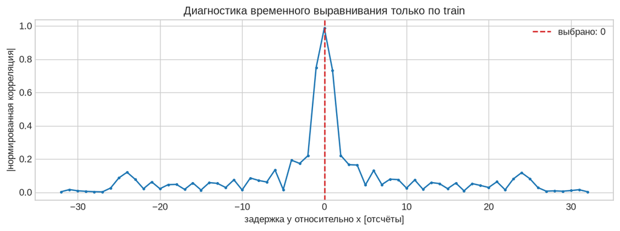

```python
# Alignment, normalization и gain оцениваются только на train.
def overlap_at_delay(x: np.ndarray, y: np.ndarray, delay: int):
    """Return overlapping vectors when y is delayed by ``delay`` vs x."""
    if delay > 0:
        return x[:-delay], y[delay:]
    if delay < 0:
        return x[-delay:], y[:delay]
    return x, y


def normalized_alignment_score(x: np.ndarray, y: np.ndarray, delay: int) -> float:
    """Return magnitude of normalized complex correlation at one delay."""
    xa, ya = overlap_at_delay(x, y, delay)
    denominator = np.sqrt(np.vdot(xa, xa).real * np.vdot(ya, ya).real)
    return float(abs(np.vdot(xa, ya)) / denominator)


ALIGNMENT_DELAYS = np.arange(-32, 33)
alignment_scores = np.array([
    normalized_alignment_score(train_x_raw, train_y_raw, int(delay))
    for delay in ALIGNMENT_DELAYS
])
integer_delay = int(ALIGNMENT_DELAYS[np.argmax(alignment_scores)])
peak_index = int(np.argmax(alignment_scores))
fractional_offset = 0.0
if 0 < peak_index < alignment_scores.size - 1:
    left_score, peak_score, right_score = alignment_scores[peak_index - 1:peak_index + 2]
    curvature = left_score - 2.0 * peak_score + right_score
    if abs(curvature) > 1e-15:
        fractional_offset = float(0.5 * (left_score - right_score) / curvature)
fractional_delay_diagnostic = integer_delay + fractional_offset

# Один train-only integer delay применяется без переоценки на validation.
train_x_aligned, train_y_aligned = overlap_at_delay(train_x_raw, train_y_raw, integer_delay)
val_x_aligned, val_y_aligned = overlap_at_delay(val_x_raw, val_y_raw, integer_delay)

TRAIN_INPUT_PEAK = float(np.max(np.abs(train_x_aligned)))
train_x = train_x_aligned / TRAIN_INPUT_PEAK
train_y = train_y_aligned / TRAIN_INPUT_PEAK
val_x = val_x_aligned / TRAIN_INPUT_PEAK
val_y = val_y_aligned / TRAIN_INPUT_PEAK

gain = np.vdot(train_x, train_y) / np.vdot(train_x, train_x)
print(f"train-only integer delay = {integer_delay} samples")
print(f"fractional-delay diagnostic = {fractional_delay_diagnostic:+.6f} samples (not applied)")
print(f"alignment peak score = {alignment_scores[peak_index]:.6f}")
print(f"train-only scale = {TRAIN_INPUT_PEAK:.6f}")
print(f"train-only complex gain = {gain.real:.8f} {gain.imag:+.8f}j")
print("normalized peaks:", *(f"{np.max(np.abs(v)):.6f}" for v in (train_x, train_y, val_x, val_y)))

fig, ax = plt.subplots(figsize=(9.5, 3.6))
ax.plot(ALIGNMENT_DELAYS, alignment_scores, marker=".", ms=4)
ax.axvline(integer_delay, color="tab:red", ls="--", label=f"выбрано: {integer_delay}")
ax.set(xlabel="задержка y относительно x [отсчёты]", ylabel="|нормированная корреляция|",
       title="Диагностика временного выравнивания только по train")
ax.legend()
plt.tight_layout()
plt.show()
```

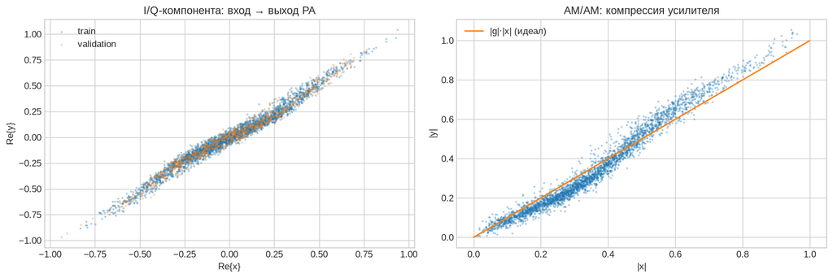

```python
# Наглядная проверка входа/выхода PA.
sample = slice(None, None, 30)
fig, axes = plt.subplots(1, 2, figsize=(13, 4.4))
axes[0].scatter(train_x.real[sample], train_y.real[sample], s=2, alpha=0.25, label="train")
axes[0].scatter(val_x.real[sample], val_y.real[sample], s=2, alpha=0.25, label="validation")
axes[0].set(xlabel="Re{x}", ylabel="Re{y}", title="I/Q-компонента: вход → выход PA")
axes[0].legend()
axes[1].scatter(np.abs(train_x)[sample], np.abs(train_y)[sample], s=2, alpha=0.25)
r = np.linspace(0, max(np.max(np.abs(train_x)), np.max(np.abs(val_x))), 200)
axes[1].plot(r, abs(gain) * r, color="tab:orange", label="|g|·|x| (идеал)")
axes[1].set(xlabel="|x|", ylabel="|y|", title="AM/AM: компрессия усилителя")
axes[1].legend()
plt.tight_layout()
plt.show()
```

## 3. Метрики

Для основной оценки используем pooled complex NMSE:

$$ \mathrm{NMSE}_{dB} = 10\log_{10} \frac{\mathbb{E}|\hat y[n]-y_\mathrm{ref}[n]|^2} {\mathbb{E}|y_\mathrm{ref}[n]|^2}. $$

Чем меньше (более отрицательно) NMSE, тем лучше. Первые отсчёты после сброса причинного состояния исключаются из оценки.

Временное отношение RMS-ошибки к RMS-эталону математически даёт то же dB-число, что pooled NMSE, поэтому оно не выдаётся за отдельную EVM. Стандартная QAM EVM потребовала бы демодуляции, синхронизации, эквализации и известных идеальных символов; этих данных здесь нет.

```python
def pooled_nmse_db(estimate: np.ndarray, reference: np.ndarray, warmup: int = 0) -> float:
    """Return pooled complex NMSE in dB after a causal warm-up.

    Args:
        estimate: Predicted complex output.
        reference: Desired/reference complex output.
        warmup: Number of record-start samples excluded from scoring.

    Returns:
        ``10*log10(MSE / reference_power)``.
    """
    estimate = np.asarray(estimate, dtype=np.complex128)
    reference = np.asarray(reference, dtype=np.complex128)
    if estimate.shape != reference.shape or estimate.ndim != 1:
        raise ValueError("metric vectors must be equal 1-D arrays")
    e = estimate[warmup:] - reference[warmup:]
    ref = reference[warmup:]
    return float(10.0 * np.log10(np.mean(np.abs(e) ** 2) / np.mean(np.abs(ref) ** 2)))


def normalized_rms_error_db(estimate: np.ndarray, reference: np.ndarray, warmup: int = 0) -> float:
    """Return time-domain normalized RMS error; equal to NMSE in dB."""
    e = np.asarray(estimate)[warmup:] - np.asarray(reference)[warmup:]
    ref = np.asarray(reference)[warmup:]
    return float(20.0 * np.log10(np.sqrt(np.mean(np.abs(e) ** 2)) / np.sqrt(np.mean(np.abs(ref) ** 2))))


def summary(signal: np.ndarray) -> dict[str, float]:
    """Summarize RMS amplitude, peak amplitude and PAPR of a signal."""
    power = float(np.mean(np.abs(signal) ** 2))
    peak = float(np.max(np.abs(signal)))
    return {
        "rms": float(np.sqrt(power)),
        "peak": peak,
        "papr_db": float(10.0 * np.log10(peak * peak / power)),
    }


def metric_row(name: str, estimate: np.ndarray, reference: np.ndarray, warmup: int) -> dict:
    """Build one readable report row from the common metric functions."""
    return {
        "name": name,
        "nmse_db": pooled_nmse_db(estimate, reference, warmup),
        **summary(estimate),
    }


# Algebraic identity check; this is why no independent EVM column is shown.
_metric_probe = np.array([1 + 1j, 0.5 - 0.2j])
assert abs(pooled_nmse_db(0.9 * _metric_probe, _metric_probe)
           - normalized_rms_error_db(0.9 * _metric_probe, _metric_probe)) < 1e-12
```

## 4. Frozen GMP-модель PA

Для evaluator используем causal generalized memory polynomial:

$$ \begin{aligned} \hat y[n] ={}&\sum_{k,q}a_{kq}x[n-q]|x[n-q]|^k\\ &+\sum_{k,q,l}b_{kql}x[n-q]|x[n-q-l]|^k\\ &+\sum_{k,q,l}c_{kql}x[n-q]|x[n-q+l]|^k. \end{aligned} $$

Последняя группа ограничена условием `lead ≤ signal_delay`, поэтому в ноутбуке нет look-ahead. Коэффициенты находятся комплексной ridge- регрессией на train; после этого PA больше не дообучается.

```python
def causal_delay(signal: np.ndarray, delay: int) -> np.ndarray:
    """Apply a causal integer delay with zero padding at record start."""
    out = np.zeros_like(signal, dtype=np.complex128)
    if delay == 0:
        out[:] = signal
    elif delay > 0:
        out[delay:] = signal[:-delay]
    return out


def gmp_terms(ka=9, la=9, kb=3, lb=7, mb=3, kc=3, lc=7, mc=3):
    """Enumerate causal GMP terms as ``(branch, order, q, envelope_q)``."""
    terms = []
    for exponent in range(ka):
        for q in range(la):
            terms.append(("aligned", exponent, q, q))
    for exponent in range(1, kb + 1):
        for q in range(lb):
            for lag in range(1, mb + 1):
                terms.append(("lagging", exponent, q, q + lag))
    for exponent in range(1, kc + 1):
        for q in range(lc):
            for lead in range(1, mc + 1):
                if lead <= q:  # causal-leading policy
                    terms.append(("leading", exponent, q, q - lead))
    return tuple(terms)


def gmp_design(signal: np.ndarray, terms: tuple) -> np.ndarray:
    """Construct the dense complex GMP design matrix in term order."""
    signal = np.asarray(signal, dtype=np.complex128)
    columns = []
    for _branch, exponent, signal_delay, envelope_delay in terms:
        delayed = causal_delay(signal, signal_delay)
        if exponent == 0:
            columns.append(delayed)
        else:
            envelope = np.abs(causal_delay(signal, envelope_delay))
            columns.append(delayed * envelope ** exponent)
    return np.column_stack(columns)


def fit_complex_ridge(design: np.ndarray, target: np.ndarray, ridge: float) -> np.ndarray:
    """Fit complex coefficients with column scaling and ridge regularization.

    The data term is normalized by the number of samples, matching the
    frozen PA-selection protocol used for the BlackBox experiment.
    """
    design = np.asarray(design, dtype=np.complex128)
    target = np.asarray(target, dtype=np.complex128)
    column_rms = np.sqrt(np.mean(np.abs(design) ** 2, axis=0))
    if np.any(column_rms <= 0) or not np.all(np.isfinite(column_rms)):
        raise ValueError("invalid design column scale")
    # The project protocol minimizes mean squared error + ridge:
    # ||D c - q||²/N + ridge*||c||².  Dividing both data and target
    # by sqrt(N) is therefore part of the definition, not cosmetic
    # numerical scaling.
    normalization = np.sqrt(float(design.shape[0]))
    scaled = design / column_rms / normalization
    normalized_target = target / normalization
    if ridge > 0:
        regularizer = np.sqrt(ridge) * np.eye(
            scaled.shape[1], dtype=np.complex128
        )
        augmented = np.vstack((scaled, regularizer))
        augmented_target = np.concatenate(
            (normalized_target, np.zeros(scaled.shape[1], dtype=np.complex128))
        )
    else:
        augmented, augmented_target = scaled, normalized_target
    coeff_scaled = np.linalg.lstsq(augmented, augmented_target, rcond=None)[0]
    return coeff_scaled / column_rms


# Frozen evaluator configuration selected on the BlackBox validation split.
# The PA is auxiliary: its complexity is not the deployment DPD budget.
pa_terms = gmp_terms()
assert len(pa_terms) == 189
# Forward identification: measured PA input x -> measured output y.
started = time.perf_counter()
pa_design = gmp_design(train_x, pa_terms)
pa_coefficients = fit_complex_ridge(pa_design, train_y, ridge=1e-10)
pa_fit_seconds = time.perf_counter() - started
del pa_design
pa_train_hat = gmp_design(train_x, pa_terms) @ pa_coefficients
pa_val_design = gmp_design(val_x, pa_terms)
pa_val_hat = pa_val_design @ pa_coefficients
del pa_val_design
print(f"GMP terms: {len(pa_terms)} complex coefficients")
print(f"fit time: {pa_fit_seconds:.2f} s")
print(f"PA validation fidelity: {pooled_nmse_db(pa_val_hat, val_y, warmup=11):.3f} dB NMSE")
```

```
GMP terms: 189 complex coefficients
fit time: 15.13 s
PA validation fidelity: -28.590 dB NMSE
```

```python
# До DPD: каскад frozen PA на желаемом validation input.
PA_WARMUP = 9
DPD_WARMUP = 2
CASCADE_WARMUP = PA_WARMUP + DPD_WARMUP
ideal_val = gain * val_x
measured_no_dpd = metric_row("measured y (diagnostic)", val_y, ideal_val, CASCADE_WARMUP)
surrogate_no_dpd = metric_row("frozen PA, no DPD", pa_val_hat, ideal_val, CASCADE_WARMUP)
print(measured_no_dpd)
print(surrogate_no_dpd)
```

```
{'name': 'measured y (diagnostic)', 'nmse_db': -15.780644671422813, 'rms': 0.4096629648882422, 'peak': 1.0855304876366918, 'papr_db': 8.464306429911977}
{'name': 'frozen PA, no DPD', 'nmse_db': -16.010350840411487, 'rms': 0.409481190602304, 'peak': 1.054000357713985, 'papr_db': 8.212136018094977}
```

## 5. Архитектура spline-memory DPD

DPD имеет три causal-ветви:

$$ z[n] = \sum_{m=0}^{2} x[n-m]\,C_m(|x[n-m]|). $$

Здесь $x[n]$ — желаемый комплексный I/Q-отсчёт, $z[n]$ — отсчёт перед PA, а $C_m(r)$ — комплексная коррекция ветви задержки $m$. Модуль $C_m$ задаёт амплитуду вклада, аргумент — фазу.

Каждая комплексная функция `C_m(r)` — кусочно-линейный сплайн с общими квантильными узлами `r_0,…,r_{K-1}`:

$$ C_m(r)=(1-\alpha)C_{m,k}+\alpha C_{m,k+1}, \qquad \alpha=\frac{r-r_k}{r_{k+1}-r_k}. $$

На каждом отсчёте активны только два соседних коэффициента. При общем повороте $x'[n]=x[n]e^{j\varphi}$ модули не меняются: $|x'[n-m]|=|x[n-m]|$. Поэтому каждый член получает один множитель $e^{j\varphi}$ и сохраняется фазовая эквивариантность:

$$ D(xe^{j\varphi})=D(x)e^{j\varphi}. $$

Калибровка ILA — только способ получить коэффициенты:

$$ u[n]=y[n]/g,\qquad \min_C\|\Phi(u)C-x\|_2^2+\lambda\|C\|_2^2. $$

На validation/test deployment-вход меняется на `x_desired`; measured `y_val` не подаётся внутрь DPD.

В основной DPA/APA конфигурации проекта исследовалась другая связь $x[n-m]C_m(|x[n]|)$, то есть ветви `((0,0),(1,0),(2,0))`. Ниже обе топологии проверяются на BlackBox. Общая текущая амплитуда здесь не принимается заранее как лучшая.

```python
def make_quantile_knots(signal: np.ndarray, count: int) -> np.ndarray:
    """Place strictly increasing interpolation knots by amplitude quantiles."""
    radius = np.abs(np.asarray(signal, dtype=np.complex128))
    unit = np.linspace(0.0, 1.0, count)
    knots = np.quantile(radius, unit)
    knots[0] = 0.0
    knots[-1] = np.max(radius)
    knots = np.unique(knots)
    if knots.size < 2 or np.any(np.diff(knots) <= 0):
        raise ValueError("quantile knots are not strictly increasing")
    return knots


def spline_coordinates(radius: np.ndarray, knots: np.ndarray):
    """Return left-knot indices and local linear interpolation weights."""
    clipped = np.clip(np.asarray(radius, dtype=float), knots[0], knots[-1])
    left = np.searchsorted(knots, clipped, side="right") - 1
    left = np.clip(left, 0, knots.size - 2)
    weight = (clipped - knots[left]) / (knots[left + 1] - knots[left])
    return left.astype(np.int64), weight


def spline_memory_design(signal: np.ndarray, knots: np.ndarray, branches: tuple[tuple[int, int], ...]) -> np.ndarray:
    """Build ``Phi[n,bK+k] = x[n-m] B_k(|x[n-d]|)`` for spline-memory DPD."""
    signal = np.asarray(signal, dtype=np.complex128)
    columns = []
    for signal_delay, envelope_delay in branches:
        delayed_signal = causal_delay(signal, signal_delay)
        delayed_envelope = causal_delay(signal, envelope_delay)
        left, weight = spline_coordinates(np.abs(delayed_envelope), knots)
        basis = np.zeros((signal.size, knots.size), dtype=float)
        rows = np.arange(signal.size)
        basis[rows, left] = 1.0 - weight
        basis[rows, left + 1] += weight
        columns.extend((delayed_signal[:, None] * basis).T)
    return np.column_stack(columns)


def fit_spline_memory_dpd(calibration_input, target, knots, branches, ridge):
    """Fit the ILA spline-memory coefficients on the causal steady region."""
    warmup = max(max(b) for b in branches)
    design = spline_memory_design(calibration_input, knots, branches)[warmup:]
    # The frozen project protocol intentionally uses the raw spline
    # dictionary here (no column scaling), with the same normalized
    # objective and ridge as factorize_spline_group().
    normalization = np.sqrt(float(design.shape[0]))
    solve_design = design / normalization
    solve_target = target[warmup:] / normalization
    augmented = np.vstack(
        (solve_design, np.sqrt(ridge) * np.eye(design.shape[1], dtype=np.complex128))
    )
    augmented_target = np.concatenate(
        (solve_target, np.zeros(design.shape[1], dtype=np.complex128))
    )
    flat = np.linalg.lstsq(augmented, augmented_target, rcond=None)[0]
    return flat.reshape(len(branches), knots.size), warmup


def predict_spline_memory(signal, knots, branches, coefficients):
    """Evaluate the causal spline-memory DPD for one independent record."""
    signal = np.asarray(signal, dtype=np.complex128)
    output = np.zeros(signal.size, dtype=np.complex128)
    for branch_index, (signal_delay, envelope_delay) in enumerate(branches):
        delayed_signal = causal_delay(signal, signal_delay)
        delayed_envelope = causal_delay(signal, envelope_delay)
        left, weight = spline_coordinates(np.abs(delayed_envelope), knots)
        c = coefficients[branch_index]
        correction = c[left] + weight * (c[left + 1] - c[left])
        output += delayed_signal * correction
    return output
```

```
no DPD: -16.010351 dB
selection rule: smallest model within 0.01 dB of best
topology                        K   NMSE [dB]  real coef   fit [s]
общая текущая амплитуда         4  -11.402039         24    0.1042
общая текущая амплитуда         8  -11.413019         48    0.2501
общая текущая амплитуда        12  -11.583653         72    0.3880
общая текущая амплитуда        16  -11.720803         96    0.7681
общая текущая амплитуда        24  -11.939839        144    1.9082
общая текущая амплитуда        32  -12.111103        192    3.3771
согласованные задержки          4  -16.546080         24    0.0981
согласованные задержки          8  -16.819523         48    0.2511
согласованные задержки         12  -16.968149         72    0.4191
согласованные задержки         16  -17.080311         96    0.7248
согласованные задержки         24  -17.192240        144    1.8860
согласованные задержки         32  -17.198500        192    2.9083
selected: {'topology': 'согласованные задержки', 'branches': ((0, 0), (1, 1), (2, 2)), 'K': 24, 'nmse_db': -17.1922404374252, 'real_coefficients': 144, 'fit_seconds': 1.8860110719688237, 'finite': True, 'max_drive': 0.923164948801816}
branches: ((0, 0), (1, 1), (2, 2)) knots: 24 ridge: 0.0001
coefficients: (3, 24) fit warmup: 2
{'name': 'зафиксированный spline-memory DPD', 'nmse_db': -17.1922404374252, 'rms': 0.4031109801663174, 'peak': 1.0222165981743738, 'papr_db': 8.082366012598657}
improvement over frozen-PA no-DPD: 1.182 dB
```

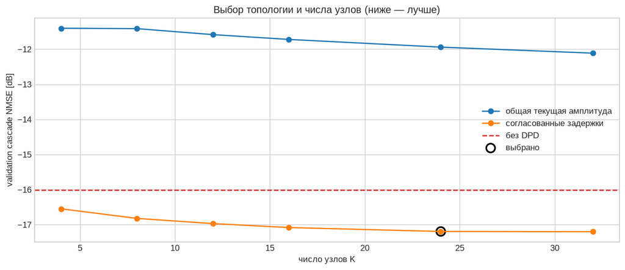

```python
# Model selection uses train for fit and validation for ranking.
# The smallest K within 0.01 dB of the best validation NMSE is retained.
TOPOLOGIES = {
    "общая текущая амплитуда": ((0, 0), (1, 0), (2, 0)),
    "согласованные задержки": ((0, 0), (1, 1), (2, 2)),
}
K_CANDIDATES = (4, 8, 12, 16, 24, 32)
RIDGE = 1e-4
NMSE_TOLERANCE_DB = 0.01
ila_input = train_y / gain
ideal_val = gain * val_x
no_dpd_nmse_db = pooled_nmse_db(pa_val_hat, ideal_val, CASCADE_WARMUP)
selection_rows = []

for topology_name, candidate_branches in TOPOLOGIES.items():
    for candidate_k in K_CANDIDATES:
        candidate_knots = make_quantile_knots(ila_input, candidate_k)
        started = time.perf_counter()
        candidate_coefficients, candidate_warmup = fit_spline_memory_dpd(
            ila_input, train_x, candidate_knots, candidate_branches, RIDGE
        )
        fit_seconds = time.perf_counter() - started
        candidate_drive = predict_spline_memory(
            val_x, candidate_knots, candidate_branches, candidate_coefficients
        )
        candidate_output = gmp_design(candidate_drive, pa_terms) @ pa_coefficients
        selection_rows.append({
            "topology": topology_name,
            "branches": candidate_branches,
            "K": candidate_k,
            "nmse_db": pooled_nmse_db(candidate_output, ideal_val, CASCADE_WARMUP),
            "real_coefficients": 2 * len(candidate_branches) * candidate_k,
            "fit_seconds": fit_seconds,
            "finite": bool(np.all(np.isfinite(candidate_coefficients))),
            "max_drive": float(np.max(np.abs(candidate_drive))),
        })

best_nmse = min(row["nmse_db"] for row in selection_rows)
eligible = [row for row in selection_rows if row["nmse_db"] <= best_nmse + NMSE_TOLERANCE_DB]
selected = min(eligible, key=lambda row: (row["real_coefficients"], row["nmse_db"]))
branches = selected["branches"]
knot_count = selected["K"]
ridge = RIDGE

print(f"no DPD: {no_dpd_nmse_db:.6f} dB")
print(f"selection rule: smallest model within {NMSE_TOLERANCE_DB:.2f} dB of best")
print(f"{'topology':29s} {'K':>3s} {'NMSE [dB]':>11s} {'real coef':>10s} {'fit [s]':>9s}")
for row in selection_rows:
    print(f"{row['topology']:29s} {row['K']:3d} {row['nmse_db']:11.6f} "
          f"{row['real_coefficients']:10d} {row['fit_seconds']:9.4f}")
print("selected:", selected)

fig, ax = plt.subplots(figsize=(10.5, 4.6))
for topology_name in TOPOLOGIES:
    rows = [row for row in selection_rows if row["topology"] == topology_name]
    ax.plot([row["K"] for row in rows], [row["nmse_db"] for row in rows],
            marker="o", label=topology_name)
ax.axhline(no_dpd_nmse_db, color="tab:red", ls="--", label="без DPD")
ax.scatter([knot_count], [selected["nmse_db"]], s=110, facecolors="none",
           edgecolors="black", linewidths=2, label="выбрано")
ax.set(xlabel="число узлов K", ylabel="validation cascade NMSE [dB]",
       title="Выбор топологии и числа узлов (ниже — лучше)")
ax.legend()
plt.tight_layout()
plt.show()

# Refit exactly the chosen configuration on train; deployment receives val_x.
knots = make_quantile_knots(ila_input, knot_count)
dpd_coefficients, dpd_fit_warmup = fit_spline_memory_dpd(
    ila_input, train_x, knots, branches, ridge
)
predistorted_val = predict_spline_memory(val_x, knots, branches, dpd_coefficients)
cascade_dpd = gmp_design(predistorted_val, pa_terms) @ pa_coefficients
dpd_metrics = metric_row("зафиксированный spline-memory DPD", cascade_dpd, ideal_val, CASCADE_WARMUP)
no_dpd_mse = np.mean(np.abs(pa_val_hat[CASCADE_WARMUP:] - ideal_val[CASCADE_WARMUP:]) ** 2)
dpd_mse = np.mean(np.abs(cascade_dpd[CASCADE_WARMUP:] - ideal_val[CASCADE_WARMUP:]) ** 2)
improvement_db = float(10 * np.log10(no_dpd_mse / dpd_mse))
print("branches:", branches, "knots:", knots.size, "ridge:", ridge)
print("coefficients:", dpd_coefficients.shape, "fit warmup:", dpd_fit_warmup)
print(dpd_metrics)
print(f"improvement over frozen-PA no-DPD: {improvement_db:.3f} dB")
```

**Результат выбора.** На BlackBox общая текущая амплитуда `((0,0),(1,0),(2,0))` ухудшает каскад относительно режима без DPD при всех проверенных `K`. Это полезный отрицательный результат: архитектура, успешная на DPA/APA, не переносится автоматически на другой capture. Выбрана топология согласованных задержек. `K=24` — минимальная модель в пределах 0,01 dB от лучшего `K=32`, а не безусловно оптимальное число узлов. Поскольку выбор сделан по validation, нужен отдельный sealed test или физический PA для независимого финального утверждения.

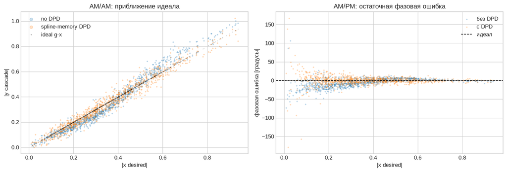

```python
# AM/AM и AM/PM residual после каскада. Идеальный выход — g*x.
n = slice(None, None, 25)
fig, axes = plt.subplots(1, 2, figsize=(13, 4.5))
axes[0].scatter(np.abs(val_x)[n], np.abs(pa_val_hat)[n], s=3, alpha=0.22, label="no DPD")
axes[0].scatter(np.abs(val_x)[n], np.abs(cascade_dpd)[n], s=3, alpha=0.22, label="spline-memory DPD")
axes[0].plot(np.abs(val_x)[n], np.abs(ideal_val)[n], ".", ms=1.0, color="black", alpha=0.18, label="ideal g·x")
axes[0].set(xlabel="|x desired|", ylabel="|y cascade|", title="AM/AM: приближение идеала")
axes[0].legend(markerscale=3)
nonzero = np.abs(ideal_val) > 1e-12
phase_no = np.degrees(np.angle(pa_val_hat[nonzero] / ideal_val[nonzero]))
phase_dpd = np.degrees(np.angle(cascade_dpd[nonzero] / ideal_val[nonzero]))
radius_nonzero = np.abs(val_x[nonzero])
axes[1].scatter(radius_nonzero[n], phase_no[n], s=3, alpha=0.20, label="без DPD")
axes[1].scatter(radius_nonzero[n], phase_dpd[n], s=3, alpha=0.20, label="с DPD")
axes[1].axhline(0, color="black", lw=1, ls="--", label="идеал")
axes[1].set(xlabel="|x desired|", ylabel="фазовая ошибка [градусы]",
            title="AM/PM: остаточная фазовая ошибка")
axes[1].legend()
plt.tight_layout()
plt.show()
```

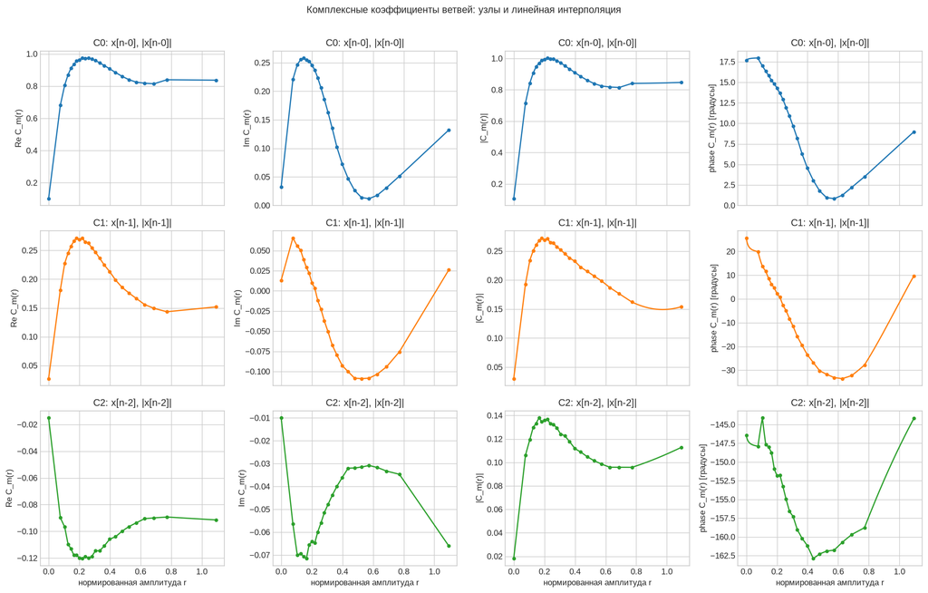

```python
# Комплексные сплайн-коэффициенты показываются по ветвям и единицам.
dense_radius = np.linspace(knots[0], knots[-1], 500)
dense_left, dense_weight = spline_coordinates(dense_radius, knots)
fig, axes = plt.subplots(3, 4, figsize=(16, 10), sharex=True)
component_names = ("Re C_m(r)", "Im C_m(r)", "|C_m(r)|", "phase C_m(r) [градусы]")
for branch_index, (signal_delay, envelope_delay) in enumerate(branches):
    c = dpd_coefficients[branch_index]
    interpolated = c[dense_left] + dense_weight * (c[dense_left + 1] - c[dense_left])
    knot_values = (c.real, c.imag, np.abs(c), np.degrees(np.angle(c)))
    dense_values = (interpolated.real, interpolated.imag, np.abs(interpolated),
                    np.degrees(np.angle(interpolated)))
    for column, (ylabel, dense_value, knot_value) in enumerate(
        zip(component_names, dense_values, knot_values)
    ):
        axis = axes[branch_index, column]
        axis.plot(dense_radius, dense_value, color=f"C{branch_index}")
        axis.plot(knots, knot_value, "o", ms=3.5, color=f"C{branch_index}")
        axis.set_ylabel(ylabel)
        axis.set_title(f"C{branch_index}: x[n-{signal_delay}], |x[n-{envelope_delay}]|")
        if branch_index == len(branches) - 1:
            axis.set_xlabel("нормированная амплитуда r")
fig.suptitle("Комплексные коэффициенты ветвей: узлы и линейная интерполяция", y=1.01)
plt.tight_layout()
plt.show()
```

```
n = 148
u0: r=0.238663, C0(r)=0.972695+0.223808j, u0=0.021957-0.237198j
u1: r=0.297460, C1(r)=0.249687-0.045822j, u1=0.072781-0.020127j
u2: r=0.520994, C2(r)=-0.096687-0.031545j, u2=-0.043470-0.030297j
z[n] = u0+u1+u2 = 0.051267-0.287622j
```

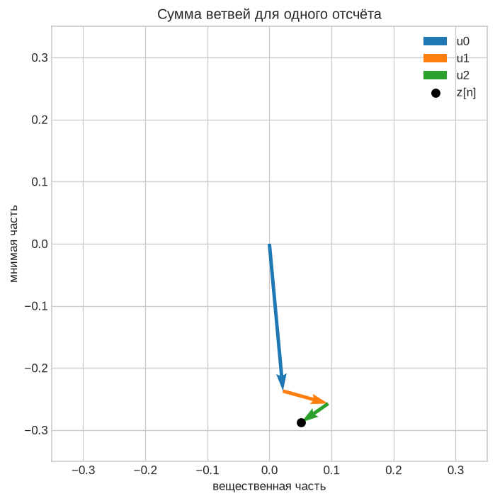

```python
# Один отсчёт: разложение z[n] на три комплексных вклада.
example_n = CASCADE_WARMUP + 137
contributions = []
example_values = []
for branch_index, (signal_delay, envelope_delay) in enumerate(branches):
    radius = abs(val_x[example_n - envelope_delay])
    left, weight = spline_coordinates(np.array([radius]), knots)
    c_value = (dpd_coefficients[branch_index, left[0]]
               + weight[0] * (dpd_coefficients[branch_index, left[0] + 1]
                              - dpd_coefficients[branch_index, left[0]]))
    contribution = val_x[example_n - signal_delay] * c_value
    contributions.append(contribution)
    example_values.append((radius, c_value))
z_example = sum(contributions)
assert abs(z_example - predistorted_val[example_n]) < 1e-12

print(f"n = {example_n}")
for index, ((radius, c_value), contribution) in enumerate(zip(example_values, contributions)):
    print(f"u{index}: r={radius:.6f}, C{index}(r)={c_value:.6f}, u{index}={contribution:.6f}")
print(f"z[n] = u0+u1+u2 = {z_example:.6f}")

fig, ax = plt.subplots(figsize=(6.4, 6.0))
origin = 0j
for index, contribution in enumerate(contributions):
    ax.quiver(origin.real, origin.imag, contribution.real, contribution.imag,
              angles="xy", scale_units="xy", scale=1, width=0.008,
              color=f"C{index}", label=f"u{index}")
    origin += contribution
ax.scatter([z_example.real], [z_example.imag], color="black", s=45, label="z[n]")
extent = 1.2 * max(abs(z_example), *(abs(value) for value in contributions), 1e-3)
ax.set(xlim=(-extent, extent), ylim=(-extent, extent), xlabel="вещественная часть",
       ylabel="мнимая часть", title="Сумма ветвей для одного отсчёта")
ax.set_aspect("equal", adjustable="box")
ax.legend()
plt.tight_layout()
plt.show()
```

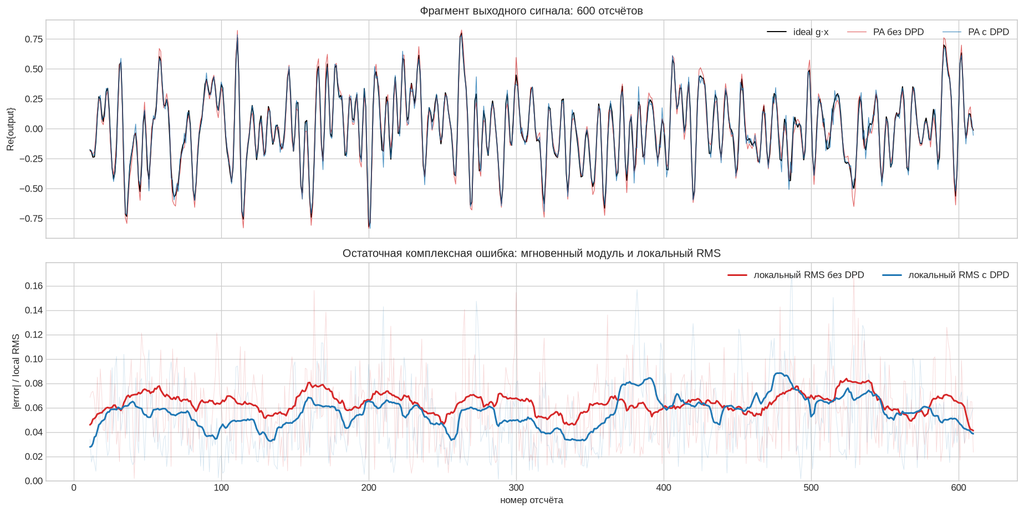

```python
# A 600-sample view is wide enough to show a representative fragment
# without compressing all fast waveform variations into one band.
fragment_length = 600
window = slice(CASCADE_WARMUP, CASCADE_WARMUP + fragment_length)
sample_axis = np.arange(fragment_length) + CASCADE_WARMUP
fig, axes = plt.subplots(2, 1, figsize=(15.5, 7.8), sharex=True)
axes[0].plot(sample_axis, ideal_val[window].real, color="black", lw=1.15, label="ideal g·x")
axes[0].plot(sample_axis, pa_val_hat[window].real, color="tab:red", alpha=0.68, lw=0.75, label="PA без DPD")
axes[0].plot(sample_axis, cascade_dpd[window].real, color="tab:blue", alpha=0.78, lw=0.75, label="PA с DPD")
axes[0].set_ylabel("Re{output}")
axes[0].set_title("Фрагмент выходного сигнала: 600 отсчётов")
axes[0].legend(loc="upper right", ncols=3)

error_no_dpd = (pa_val_hat - ideal_val)[window]
error_with_dpd = (cascade_dpd - ideal_val)[window]

def local_rms(signal: np.ndarray, width=25) -> np.ndarray:
    """Return a centered moving RMS envelope for plot readability."""
    kernel = np.ones(width, dtype=float) / width
    return np.sqrt(np.convolve(np.abs(signal) ** 2, kernel, mode="same"))

# Magnitude avoids the visually misleading up/down sign flips of Re{e};
# faint samples preserve detail and thick curves show the local trend.
axes[1].plot(sample_axis, np.abs(error_no_dpd), color="tab:red", lw=0.55, alpha=0.18)
axes[1].plot(sample_axis, np.abs(error_with_dpd), color="tab:blue", lw=0.55, alpha=0.18)
axes[1].plot(sample_axis, local_rms(error_no_dpd), color="tab:red", lw=1.8, label="локальный RMS без DPD")
axes[1].plot(sample_axis, local_rms(error_with_dpd), color="tab:blue", lw=1.8, label="локальный RMS с DPD")
axes[1].set(
    xlabel="номер отсчёта",
    ylabel="|error| / local RMS",
    title="Остаточная комплексная ошибка: мгновенный модуль и локальный RMS",
)
axes[1].set_ylim(bottom=0)
axes[1].legend(loc="upper right", ncols=2)
plt.tight_layout()
plt.show()
```

## 6. Спектральная диагностика

Мы считаем Welch-подобную PSD с `fs=1` только для визуального сравнения формы спектра. Ось — циклы на отсчёт. Без sample rate и заранее заданных RF-регионов нельзя переводить это в dBc/ACLR.

Показана Welch-оценка после небольшого сглаживания в линейной мощности. Чёрный пунктир — спектр реального желаемого сигнала $g x$, а не плоская теоретическая маска.

Сглаживание выполняется **в линейной мощности до перевода в dB**. Оно делает рисунок читаемым, но не меняет данные и не используется при расчёте NMSE или обучении модели.

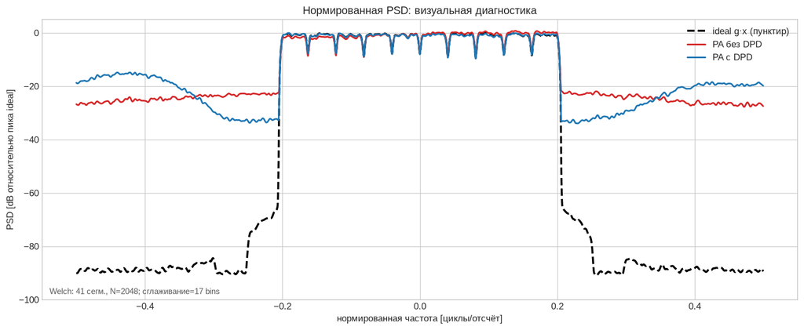

```python
def welch_complex(signal: np.ndarray, nperseg=2048, noverlap=1536):
    """Estimate a normalized-frequency Welch PSD for a complex vector."""
    signal = np.asarray(signal, dtype=np.complex128)
    step = nperseg - noverlap
    window = np.hanning(nperseg)
    scale = np.sum(window ** 2)
    starts = range(0, signal.size - nperseg + 1, step)
    spectra = []
    for start in starts:
        segment = signal[start:start + nperseg]
        spectra.append(np.abs(np.fft.fftshift(np.fft.fft(segment * window))) ** 2 / scale)
    if not spectra:
        raise ValueError("signal is shorter than nperseg")
    power = np.mean(np.stack(spectra), axis=0)
    frequency = np.fft.fftshift(np.fft.fftfreq(nperseg, d=1.0))
    return frequency, power


def smooth_linear_power(power: np.ndarray, bins=17) -> np.ndarray:
    """Smooth PSD samples in linear power with an odd Hann kernel."""
    power = np.asarray(power, dtype=float)
    bins = int(bins)
    if bins < 3:
        return power.copy()
    if bins % 2 == 0:
        bins += 1
    kernel = np.hanning(bins)
    kernel /= np.sum(kernel)
    pad = bins // 2
    padded = np.pad(power, (pad, pad), mode="edge")
    return np.convolve(padded, kernel, mode="valid")


# A shorter segment gives more Welch averages on the 23k-sample
# validation set; the mild frequency smoothing is presentation-only.
PSD_NPERSEG = 2048
PSD_NOVERLAP = 1536
PSD_SMOOTH_BINS = 17
psd_signals = {
    "ideal": ideal_val[CASCADE_WARMUP:],
    "no DPD": pa_val_hat[CASCADE_WARMUP:],
    "with DPD": cascade_dpd[CASCADE_WARMUP:],
}
psd = {
    name: welch_complex(signal, PSD_NPERSEG, PSD_NOVERLAP)
    for name, signal in psd_signals.items()
}
psd_smooth = {
    name: (frequency, smooth_linear_power(power, PSD_SMOOTH_BINS))
    for name, (frequency, power) in psd.items()
}
reference_peak = np.max(psd_smooth["ideal"][1])

colors = {"ideal": "black", "no DPD": "tab:red", "with DPD": "tab:blue"}
labels = {
    "ideal": "ideal g·x (пунктир)",
    "no DPD": "PA без DPD",
    "with DPD": "PA с DPD",
}
fig, ax = plt.subplots(figsize=(12.5, 5.2))

for name, (frequency, power) in psd_smooth.items():
    smooth_db = 10 * np.log10(np.maximum(power, 1e-30) / reference_peak)
    style = {
        "color": colors[name],
        "linestyle": "--" if name == "ideal" else "-",
        "linewidth": 2.2 if name == "ideal" else 1.8,
    }
    ax.plot(frequency, smooth_db, label=labels[name], **style)

segment_step = PSD_NPERSEG - PSD_NOVERLAP
segment_count = 1 + (len(psd_signals["ideal"]) - PSD_NPERSEG) // segment_step
ax.set(
    xlabel="нормированная частота [циклы/отсчёт]",
    ylabel="PSD [dB относительно пика ideal]",
    title="Нормированная PSD: визуальная диагностика",
)
ax.set_ylim(-100, 5)
ax.legend(loc="best")
ax.text(
    0.01,
    0.02,
    f"Welch: {segment_count} сегм., N={PSD_NPERSEG}; сглаживание={PSD_SMOOTH_BINS} bins",
    transform=ax.transAxes,
    fontsize=9,
    color="0.35",
)
plt.tight_layout()
plt.show()
```

**Как читать график.** Цветные линии сравнивают выход PA до и после предыскажения с желаемым спектром. Провалы чёрного пунктира принадлежат структуре исходного сигнала (например, незаполненным частотным компонентам), поэтому идеальная линия здесь не обязана быть горизонтальной.

Нелинейность PA перераспределяет энергию между частотами и создаёт спектральное разрастание. DPD обучается по временной комплексной ошибке NMSE, а не по спектральной маске, поэтому улучшение следует оценивать по совокупности PSD и NMSE, не по одному локальному провалу кривой. Численный ACLR не рассчитан: официальные границы основной и соседних полос, а также частота дискретизации для этого capture неизвестны.

## 7. Вычислительная сложность

Ниже стоимость вычисляется из фактических `branches` и `K`. Конвенция проекта считает обычное комплексное умножение как 4 real MUL + 2 real ADD; интерполяция комплексного коэффициента требует ещё 2 real MUL. Вычисление модуля, сравнения/поиск интервала, LUT и состояние вынесены отдельно. Это аналитическая стоимость Python-equivalent алгоритма, а не измеренная задержка FPGA/ASIC и не подтверждённый PASS по ориентиру 1000.

```python
def spline_fast_path_complexity(branches, knot_count):
    """Count operations under the project's explicit scalar convention."""
    branch_count = len(branches)
    unique_envelope_delays = len({envelope_delay for _, envelope_delay in branches})
    maximum_delay = max(max(pair) for pair in branches)
    return {
        "real_multiplications": 6 * branch_count + 3 * unique_envelope_delays,
        "real_additions": 8 * branch_count - 2 + 2 * unique_envelope_delays,
        "magnitude_operations": unique_envelope_delays,
        "comparisons": int(np.ceil(np.log2(knot_count))) * unique_envelope_delays,
        "LUT_reads": 2 * branch_count,
        "stored_complex_coefficients": branch_count * knot_count,
        "stored_real_coefficients": 2 * branch_count * knot_count,
        "state_complex_values": maximum_delay,
        "state_real_values": 2 * maximum_delay,
    }


complexity = spline_fast_path_complexity(branches, knot_count)
print(json.dumps(complexity, ensure_ascii=False, indent=2))
print("Параметры других моделей здесь не рисуются рядом с MUL/sample: это разные величины.")
```

```
{
  "real_multiplications": 27,
  "real_additions": 28,
  "magnitude_operations": 3,
  "comparisons": 15,
  "LUT_reads": 6,
  "stored_complex_coefficients": 72,
  "stored_real_coefficients": 144,
  "state_complex_values": 2,
  "state_real_values": 4
}
Параметры других моделей здесь не рисуются рядом с MUL/sample: это разные величины.
```

## 8. Fixed-point статус

Этот BlackBox notebook проверяет только float64-реализацию. Программные 16/14/12-bit результаты проекта относятся к отдельным DPA/APA экспериментам и сюда не переносятся. Для BlackBox ещё требуется отдельный bit-accurate запуск с подсчётом насыщений, коллизий узлов, спектральной деградации и совпадения потоковой обработки.

## 9. Справочное сравнение только с OpenDPD

Ниже считываются bundled machine-readable результаты OpenDPD для `APA_200MHz`. Это официальный для данного репозитория reference table: MP/GMP используют ILA, GRU и TRes-GRU — DLA через frozen TRes-GRU PA.

### Как читать этот блок

Это **встроенный reference OpenDPD**, а не повторное обучение OpenDPD внутри данного ноутбука. Если рядом с notebook нет репозитория OpenDPD, используется сохранённая компактная копия этих четырёх строк. Если репозиторий найден, числа читаются из его JSON автоматически.

| Поле | Смысл в OpenDPD |
| --- | --- |
| `NMSE` | repository-specific segment-wise normalized error |
| `EVM` | repository-specific spectral EVM |
| `ACLRavg` | среднее левой и правой соседних областей |
| `parameters` | число параметров/комплексных степеней свободы в bundled benchmark |

Во всех трёх dB-метриках более отрицательное число означает меньшую ошибку или утечку. График ниже показывает только внутреннее ранжирование OpenDPD; строка нашего BlackBox эксперимента в эти столбцы не подмешивается.

Сравнение с BlackBox нельзя подписать как «наш метод лучше/хуже», потому что:

1. BlackBox — другой capture, без sample rate/RF-mask metadata;
2. OpenDPD — `APA_200MHz`, другой evaluator и другой split;
3. OpenDPD NMSE — среднее segment-wise dB, а здесь pooled complex NMSE;
4. OpenDPD EVM/ACLR имеют собственные definitions и недоступны честно для BlackBox без частотных границ.

Поэтому следующий график сравнивает модели **внутри OpenDPD между собой**, а наши BlackBox-цифры остаются отдельной строкой контекста.

```python
OPENDPD_FALLBACK = {
    "source_commit": "3df35e081e6e41463fa46f21778c72a748823274",
    "dataset": "APA_200MHz",
    "models": {
        "MP": {"parameters": 1000, "nmse_db": -42.1896324, "evm_db": -48.1534769, "aclr_avg_db": -45.1859831},
        "GMP": {"parameters": 1000, "nmse_db": -38.5258979, "evm_db": -46.3523044, "aclr_avg_db": -43.5931687},
        "GRU-H16": {"parameters": 994, "nmse_db": -45.13145, "evm_db": -47.4274689, "aclr_avg_db": -51.0114043},
        "TRes-GRU-H15": {"parameters": 999, "nmse_db": -44.285923, "evm_db": -45.0972778, "aclr_avg_db": -53.4879386},
    },
}


opendpd_reference = OPENDPD_FALLBACK.copy()
if OPENDPD_JSON.is_file():
    with OPENDPD_JSON.open(encoding="utf-8") as stream:
        report = json.load(stream)
    apa = report["datasets"]["APA_200MHz"]["dpd_models"]
    name_map = {"mp": "MP", "gmp": "GMP", "gru": "GRU-H16", "tres_gru": "TRes-GRU-H15"}
    opendpd_reference = {
        "source_commit": report["completion_context"]["git_commit"],
        "dataset": "APA_200MHz",
        "models": {
            name_map[key]: {
                "parameters": value["model"]["parameters"],
                "nmse_db": value["metrics"]["test"]["nmse_db"],
                "evm_db": value["metrics"]["test"]["evm_db"],
                "aclr_avg_db": value["metrics"]["test"]["aclr_avg_db"],
            }
            for key, value in apa.items()
        },
    }
OPENDPD_ORDER = ["MP", "GMP", "GRU-H16", "TRes-GRU-H15"]
print("=" * 78)
print("OpenDPD BUNDLED REFERENCE | APA_200MHz | TEST SPLIT")
print("source commit:", opendpd_reference["source_commit"])
print("not retrained by this notebook; metrics follow OpenDPD definitions")
print("-" * 78)
print(f"{'model':16s} {'parameters':>10s} {'NMSE [dB]':>12s} {'EVM [dB]':>12s} {'ACLRavg [dB]':>14s}")
print("-" * 78)
for name in OPENDPD_ORDER:
    values = opendpd_reference["models"][name]
    print(f"{name:16s} {values['parameters']:10d} {values['nmse_db']:12.3f} {values['evm_db']:12.3f} {values['aclr_avg_db']:14.3f}")
print("=" * 78)
```

```
==============================================================================
OpenDPD BUNDLED REFERENCE | APA_200MHz | TEST SPLIT
source commit: 3df35e081e6e41463fa46f21778c72a748823274
not retrained by this notebook; metrics follow OpenDPD definitions
------------------------------------------------------------------------------
model            parameters    NMSE [dB]     EVM [dB]   ACLRavg [dB]
------------------------------------------------------------------------------
MP                     1000      -42.190      -48.153        -45.186
GMP                    1000      -38.526      -46.352        -43.593
GRU-H16                 994      -45.131      -47.427        -51.011
TRes-GRU-H15            999      -44.286      -45.097        -53.488
==============================================================================
```

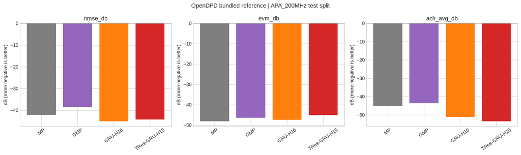

```python
names = ["MP", "GMP", "GRU-H16", "TRes-GRU-H15"]
metrics = ["nmse_db", "evm_db", "aclr_avg_db"]
fig, axes = plt.subplots(1, 3, figsize=(15, 4.5))
for axis, metric in zip(axes, metrics):
    values = [opendpd_reference["models"][name][metric] for name in names]
    axis.bar(names, values, color=["tab:gray", "tab:purple", "tab:orange", "tab:red"])
    axis.set_title(metric)
    axis.set_ylabel("dB (more negative is better)")
    axis.tick_params(axis="x", rotation=35)
    axis.axhline(0, color="black", lw=0.7)
fig.suptitle("OpenDPD bundled reference | APA_200MHz test split")
plt.tight_layout()
plt.show()
```

### Что можно заключить из сравнения

Внутри OpenDPD TRes-GRU-H15 показывает сильный reference по ACLR, а GRU-H16 — лучший NMSE среди этих строк. Напечатанный выше BlackBox pooled NMSE нельзя сопоставлять с `−44…−45 dB` OpenDPD как единый рейтинг: это разные эксперименты и разные метрики.

Корректная следующая ступень для apples-to-apples сравнения — экспортировать один и тот же BlackBox split в формат OpenDPD, обучить выбранный OpenDPD DPD через тот же frozen PA evaluator и заранее зафиксировать общий metric protocol. В ноутбуке это намеренно не подменяется неподтверждённой цифрой.

## 10. Встроенные тесты

Эти проверки не являются формальным unit-test suite проекта, но ловят самые опасные ошибки исследовательского ноутбука: перепутанное направление, нарушение фазовой эквивариантности, потерю state между блоками и выход за обученный диапазон.

```python
# 1) Данные и модель конечны.
assert np.all(np.isfinite(train_x)) and np.all(np.isfinite(val_x))
assert np.all(np.isfinite(pa_coefficients)) and np.all(np.isfinite(dpd_coefficients))
assert dpd_coefficients.shape == (len(branches), knot_count)

# 2) Правильное deployment-направление: DPD получает val_x, а не val_y.
replay_from_desired = predict_spline_memory(val_x, knots, branches, dpd_coefficients)
assert np.allclose(replay_from_desired, predistorted_val)

# 3) Фазовая эквивариантность D(e^{jφ}x)=e^{jφ}D(x).
phi = 0.731
rotated = np.exp(1j * phi) * val_x[:4000]
lhs = predict_spline_memory(rotated, knots, branches, dpd_coefficients)
rhs = np.exp(1j * phi) * predict_spline_memory(val_x[:4000], knots, branches, dpd_coefficients)
assert np.max(np.abs(lhs - rhs)) < 1e-12

# 4) Потоковая проверка: разбиваем validation на произвольные chunks.
def predict_streaming(signal, chunk_sizes):
    """Run one independent record while carrying only causal history."""
    history_size = max(max(pair) for pair in branches)
    history = np.zeros(history_size, dtype=np.complex128)
    output = []
    start = 0
    for size in chunk_sizes:
        chunk = np.asarray(signal[start:start + size], dtype=np.complex128)
        padded = np.concatenate((history, chunk))
        piece = predict_spline_memory(padded, knots, branches, dpd_coefficients)[history.size:]
        output.append(piece)
        history = padded[-history_size:] if history_size else history
        start += size
    if start < signal.size:
        chunk = np.asarray(signal[start:], dtype=np.complex128)
        padded = np.concatenate((history, chunk))
        output.append(predict_spline_memory(padded, knots, branches, dpd_coefficients)[history_size:])
    return np.concatenate(output)


streamed = predict_streaming(val_x, [1, 8, 64, 257, 1024])
reference_stream = predict_spline_memory(val_x, knots, branches, dpd_coefficients)
assert np.max(np.abs(streamed - reference_stream)) < 1e-12

# 5) Reset на границе независимого record: history train не попадает в validation.
record_a, record_b = val_x[:3000], val_x[3000:7000]
separate_b = predict_streaming(record_b, [17, 131, 509])
repeated_b = predict_streaming(record_b, [1, 29, 777])
direct_b = predict_spline_memory(record_b, knots, branches, dpd_coefficients)
assert np.max(np.abs(separate_b - direct_b)) < 1e-12
assert np.max(np.abs(repeated_b - direct_b)) < 1e-12
concatenated = predict_spline_memory(np.concatenate((record_a, record_b)), knots, branches, dpd_coefficients)
# При отсутствии reset первые memory samples второго record обычно отличаются.
assert np.max(np.abs(concatenated[record_a.size:record_a.size + DPD_WARMUP]
                     - direct_b[:DPD_WARMUP])) > 0

# 6) Никакого незаявленного extrapolation: validation desired и drive внутри train support.
assert np.max(np.abs(val_x)) <= knots[-1] * (1 + 1e-12)
assert np.max(np.abs(predistorted_val)) <= np.max(np.abs(train_x)) * (1 + 1e-12)

# 7) DPD действительно уменьшает frozen-surrogate error power.
assert dpd_mse < no_dpd_mse
print("ALL SELF-TESTS PASSED")
print(f"phase equivariance max error: {np.max(np.abs(lhs-rhs)):.3e}")
print(f"streaming max error: {np.max(np.abs(streamed-reference_stream)):.3e}")
```

```
ALL SELF-TESTS PASSED
phase equivariance max error: 2.483e-16
streaming max error: 0.000e+00
```

```python
print("КРАТКИЙ ИТОГ BLACKBOX VALIDATION")
print(f"PA evaluator fidelity: {pooled_nmse_db(pa_val_hat, val_y, PA_WARMUP):.3f} dB NMSE")
print(f"без DPD: {surrogate_no_dpd['nmse_db']:.3f} dB NMSE")
print(f"с DPD:   {dpd_metrics['nmse_db']:.3f} dB NMSE")
print(f"улучшение: {improvement_db:.3f} dB")
print(f"архитектура: {branches}; K={knot_count}; ridge={ridge:g}")
print(f"fast path: {complexity['real_multiplications']} MUL, "
      f"{complexity['real_additions']} ADD, "
      f"{complexity['magnitude_operations']} magnitude, "
      f"{complexity['LUT_reads']} LUT reads / complex sample")
print("fixed-point: не проверен на BlackBox")
```

```
КРАТКИЙ ИТОГ BLACKBOX VALIDATION
PA evaluator fidelity: -28.590 dB NMSE
без DPD: -16.010 dB NMSE
с DPD:   -17.192 dB NMSE
улучшение: 1.182 dB
архитектура: ((0, 0), (1, 1), (2, 2)); K=24; ridge=0.0001
fast path: 27 MUL, 28 ADD, 3 magnitude, 6 LUT reads / complex sample
fixed-point: не проверен на BlackBox
```

## 11. Что доказано и что не доказано

### Подтверждено этим notebook

- детерминированная загрузка и хронологический train/validation split;
- train-only alignment, normalization и complex gain;
- комплексная ridge-калибровка, фазовая эквивариантность и причинность;
- выбор топологии/K по явно указанному validation-критерию;
- совпадение цельной и chunked обработки при переносе состояния;
- корректный reset между независимыми records;
- аналитическая float fast-path стоимость.

### Не подтверждено

Физический PA после DPD, официальные Huawei bands/thresholds, стандартная EVM, fixed-point именно на BlackBox, hardware timing, переносимость на другие captures, online adaptation и apples-to-apples превосходство над OpenDPD. Следующий наиболее ценный эксперимент — один waveform и одна выходная мощность для `{без DPD / spline DPD / OpenDPD}` на одном физическом PA с заранее зафиксированными спектральными областями.